# Risk Factor Analysis

## Outcome Variable

**Outcome Variable:** pers_wast

## Predictor Variables

**Intervention Variable:** enstunt

**Adjustment Set:**

- arm
- sex
- W_mage
- meducyrs
- feducyrs
- vagbrth
- single
- brthmon
- W_parity
- delta_W_mage
- delta_meducyrs
- delta_feducyrs
- delta_vagbrth
- delta_single
- delta_brthmon
- delta_W_parity

## Stratifying Variables

The analysis was stratified on these variable(s):

- agecat
- studyid
- country

## Data Summary

| agecat | studyid | country | enstunt | pers_wast | n_cell | n |
| --- | --- | --- | --- | --- | --- | --- |
| 0-24 months | CMC-V-BCS-2002 | INDIA | 0 | 0 | 281 | 373 |
| 0-24 months | CMC-V-BCS-2002 | INDIA | 0 | 1 | 15 | 373 |
| 0-24 months | CMC-V-BCS-2002 | INDIA | 1 | 0 | 69 | 373 |
| 0-24 months | CMC-V-BCS-2002 | INDIA | 1 | 1 | 8 | 373 |
| 0-24 months | CMIN | BANGLADESH | 0 | 0 | 152 | 257 |
| 0-24 months | CMIN | BANGLADESH | 0 | 1 | 9 | 257 |
| 0-24 months | CMIN | BANGLADESH | 1 | 0 | 85 | 257 |
| 0-24 months | CMIN | BANGLADESH | 1 | 1 | 11 | 257 |
| 0-24 months | COHORTS | GUATEMALA | 0 | 0 | 826 | 1056 |
| 0-24 months | COHORTS | GUATEMALA | 0 | 1 | 22 | 1056 |
| 0-24 months | COHORTS | GUATEMALA | 1 | 0 | 194 | 1056 |
| 0-24 months | COHORTS | GUATEMALA | 1 | 1 | 14 | 1056 |
| 0-24 months | COHORTS | INDIA | 0 | 0 | 4663 | 5705 |
| 0-24 months | COHORTS | INDIA | 0 | 1 | 447 | 5705 |
| 0-24 months | COHORTS | INDIA | 1 | 0 | 492 | 5705 |
| 0-24 months | COHORTS | INDIA | 1 | 1 | 103 | 5705 |
| 0-24 months | COHORTS | PHILIPPINES | 0 | 0 | 2524 | 2811 |
| 0-24 months | COHORTS | PHILIPPINES | 0 | 1 | 127 | 2811 |
| 0-24 months | COHORTS | PHILIPPINES | 1 | 0 | 143 | 2811 |
| 0-24 months | COHORTS | PHILIPPINES | 1 | 1 | 17 | 2811 |
| 0-24 months | CONTENT | PERU | 0 | 0 | 195 | 215 |
| 0-24 months | CONTENT | PERU | 0 | 1 | 0 | 215 |
| 0-24 months | CONTENT | PERU | 1 | 0 | 20 | 215 |
| 0-24 months | CONTENT | PERU | 1 | 1 | 0 | 215 |
| 0-24 months | EE | PAKISTAN | 0 | 0 | 195 | 377 |
| 0-24 months | EE | PAKISTAN | 0 | 1 | 16 | 377 |
| 0-24 months | EE | PAKISTAN | 1 | 0 | 149 | 377 |
| 0-24 months | EE | PAKISTAN | 1 | 1 | 17 | 377 |
| 0-24 months | GMS-Nepal | NEPAL | 0 | 0 | 434 | 597 |
| 0-24 months | GMS-Nepal | NEPAL | 0 | 1 | 66 | 597 |

[output cut: 310 more lines]

The following strata were considered:

- agecat: 0-24 months, studyid: CMC-V-BCS-2002, country: INDIA
- agecat: 0-24 months, studyid: CMIN, country: BANGLADESH
- agecat: 0-24 months, studyid: COHORTS, country: GUATEMALA
- agecat: 0-24 months, studyid: COHORTS, country: INDIA
- agecat: 0-24 months, studyid: COHORTS, country: PHILIPPINES
- agecat: 0-24 months, studyid: CONTENT, country: PERU
- agecat: 0-24 months, studyid: EE, country: PAKISTAN
- agecat: 0-24 months, studyid: GMS-Nepal, country: NEPAL
- agecat: 0-24 months, studyid: Guatemala BSC, country: GUATEMALA
- agecat: 0-24 months, studyid: iLiNS-Zinc, country: BURKINA FASO
- agecat: 0-24 months, studyid: IRC, country: INDIA
- agecat: 0-24 months, studyid: JiVitA-3, country: BANGLADESH
- agecat: 0-24 months, studyid: JiVitA-4, country: BANGLADESH
- agecat: 0-24 months, studyid: Keneba, country: GAMBIA
- agecat: 0-24 months, studyid: LCNI-5, country: MALAWI
- agecat: 0-24 months, studyid: MAL-ED, country: BANGLADESH
- agecat: 0-24 months, studyid: MAL-ED, country: BRAZIL
- agecat: 0-24 months, studyid: MAL-ED, country: INDIA
- agecat: 0-24 months, studyid: MAL-ED, country: NEPAL
- agecat: 0-24 months, studyid: MAL-ED, country: PERU
- agecat: 0-24 months, studyid: MAL-ED, country: SOUTH AFRICA
- agecat: 0-24 months, studyid: MAL-ED, country: TANZANIA, UNITED REPUBLIC OF
- agecat: 0-24 months, studyid: NIH-Birth, country: BANGLADESH
- agecat: 0-24 months, studyid: NIH-Crypto, country: BANGLADESH
- agecat: 0-24 months, studyid: PROBIT, country: BELARUS
- agecat: 0-24 months, studyid: PROVIDE, country: BANGLADESH
- agecat: 0-24 months, studyid: ResPak, country: PAKISTAN
- agecat: 0-24 months, studyid: SAS-CompFeed, country: INDIA
- agecat: 0-24 months, studyid: SAS-FoodSuppl, country: INDIA
- agecat: 0-24 months, studyid: TanzaniaChild2, country: TANZANIA, UNITED REPUBLIC OF
- agecat: 0-24 months, studyid: ZVITAMBO, country: ZIMBABWE
- agecat: 0-6 months, studyid: CMC-V-BCS-2002, country: INDIA
- agecat: 0-6 months, studyid: CMIN, country: BANGLADESH
- agecat: 0-6 months, studyid: COHORTS, country: PHILIPPINES
- agecat: 0-6 months, studyid: CONTENT, country: PERU
- agecat: 0-6 months, studyid: EE, country: PAKISTAN
- agecat: 0-6 months, studyid: GMS-Nepal, country: NEPAL
- agecat: 0-6 months, studyid: IRC, country: INDIA
- agecat: 0-6 months, studyid: JiVitA-3, country: BANGLADESH
- agecat: 0-6 months, studyid: Keneba, country: GAMBIA
- agecat: 0-6 months, studyid: MAL-ED, country: BANGLADESH
- agecat: 0-6 months, studyid: MAL-ED, country: BRAZIL
- agecat: 0-6 months, studyid: MAL-ED, country: INDIA
- agecat: 0-6 months, studyid: MAL-ED, country: NEPAL
- agecat: 0-6 months, studyid: MAL-ED, country: PERU
- agecat: 0-6 months, studyid: MAL-ED, country: SOUTH AFRICA
- agecat: 0-6 months, studyid: MAL-ED, country: TANZANIA, UNITED REPUBLIC OF
- agecat: 0-6 months, studyid: NIH-Birth, country: BANGLADESH
- agecat: 0-6 months, studyid: NIH-Crypto, country: BANGLADESH
- agecat: 0-6 months, studyid: PROBIT, country: BELARUS
- agecat: 0-6 months, studyid: PROVIDE, country: BANGLADESH
- agecat: 0-6 months, studyid: ResPak, country: PAKISTAN
- agecat: 0-6 months, studyid: TanzaniaChild2, country: TANZANIA, UNITED REPUBLIC OF
- agecat: 0-6 months, studyid: ZVITAMBO, country: ZIMBABWE
- agecat: 6-24 months, studyid: CMC-V-BCS-2002, country: INDIA
- agecat: 6-24 months, studyid: CMIN, country: BANGLADESH
- agecat: 6-24 months, studyid: COHORTS, country: GUATEMALA
- agecat: 6-24 months, studyid: COHORTS, country: INDIA
- agecat: 6-24 months, studyid: COHORTS, country: PHILIPPINES
- agecat: 6-24 months, studyid: CONTENT, country: PERU
- agecat: 6-24 months, studyid: EE, country: PAKISTAN
- agecat: 6-24 months, studyid: GMS-Nepal, country: NEPAL
- agecat: 6-24 months, studyid: Guatemala BSC, country: GUATEMALA
- agecat: 6-24 months, studyid: iLiNS-Zinc, country: BURKINA FASO
- agecat: 6-24 months, studyid: IRC, country: INDIA
- agecat: 6-24 months, studyid: JiVitA-3, country: BANGLADESH
- agecat: 6-24 months, studyid: JiVitA-4, country: BANGLADESH
- agecat: 6-24 months, studyid: Keneba, country: GAMBIA
- agecat: 6-24 months, studyid: LCNI-5, country: MALAWI
- agecat: 6-24 months, studyid: MAL-ED, country: BANGLADESH
- agecat: 6-24 months, studyid: MAL-ED, country: BRAZIL
- agecat: 6-24 months, studyid: MAL-ED, country: INDIA
- agecat: 6-24 months, studyid: MAL-ED, country: NEPAL
- agecat: 6-24 months, studyid: MAL-ED, country: PERU
- agecat: 6-24 months, studyid: MAL-ED, country: SOUTH AFRICA
- agecat: 6-24 months, studyid: MAL-ED, country: TANZANIA, UNITED REPUBLIC OF
- agecat: 6-24 months, studyid: NIH-Birth, country: BANGLADESH
- agecat: 6-24 months, studyid: NIH-Crypto, country: BANGLADESH
- agecat: 6-24 months, studyid: PROBIT, country: BELARUS
- agecat: 6-24 months, studyid: PROVIDE, country: BANGLADESH
- agecat: 6-24 months, studyid: ResPak, country: PAKISTAN
- agecat: 6-24 months, studyid: SAS-CompFeed, country: INDIA
- agecat: 6-24 months, studyid: SAS-FoodSuppl, country: INDIA
- agecat: 6-24 months, studyid: TanzaniaChild2, country: TANZANIA, UNITED REPUBLIC OF
- agecat: 6-24 months, studyid: ZVITAMBO, country: ZIMBABWE

### Dropped Strata

Some strata were dropped due to rare outcomes:

- agecat: 0-24 months, studyid: CONTENT, country: PERU
- agecat: 0-24 months, studyid: Guatemala BSC, country: GUATEMALA
- agecat: 0-24 months, studyid: LCNI-5, country: MALAWI
- agecat: 0-24 months, studyid: MAL-ED, country: BANGLADESH
- agecat: 0-24 months, studyid: MAL-ED, country: BRAZIL
- agecat: 0-24 months, studyid: MAL-ED, country: INDIA
- agecat: 0-24 months, studyid: MAL-ED, country: NEPAL
- agecat: 0-24 months, studyid: MAL-ED, country: PERU
- agecat: 0-24 months, studyid: MAL-ED, country: SOUTH AFRICA
- agecat: 0-24 months, studyid: MAL-ED, country: TANZANIA, UNITED REPUBLIC OF
- agecat: 0-24 months, studyid: PROBIT, country: BELARUS
- agecat: 0-24 months, studyid: PROVIDE, country: BANGLADESH
- agecat: 0-24 months, studyid: TanzaniaChild2, country: TANZANIA, UNITED REPUBLIC OF
- agecat: 0-6 months, studyid: CMIN, country: BANGLADESH
- agecat: 0-6 months, studyid: COHORTS, country: PHILIPPINES
- agecat: 0-6 months, studyid: CONTENT, country: PERU
- agecat: 0-6 months, studyid: JiVitA-3, country: BANGLADESH
- agecat: 0-6 months, studyid: MAL-ED, country: BANGLADESH
- agecat: 0-6 months, studyid: MAL-ED, country: BRAZIL
- agecat: 0-6 months, studyid: MAL-ED, country: INDIA
- agecat: 0-6 months, studyid: MAL-ED, country: NEPAL
- agecat: 0-6 months, studyid: MAL-ED, country: PERU
- agecat: 0-6 months, studyid: MAL-ED, country: SOUTH AFRICA
- agecat: 0-6 months, studyid: MAL-ED, country: TANZANIA, UNITED REPUBLIC OF
- agecat: 0-6 months, studyid: NIH-Birth, country: BANGLADESH
- agecat: 0-6 months, studyid: NIH-Crypto, country: BANGLADESH
- agecat: 0-6 months, studyid: PROBIT, country: BELARUS
- agecat: 0-6 months, studyid: PROVIDE, country: BANGLADESH
- agecat: 0-6 months, studyid: TanzaniaChild2, country: TANZANIA, UNITED REPUBLIC OF
- agecat: 0-6 months, studyid: ZVITAMBO, country: ZIMBABWE
- agecat: 6-24 months, studyid: CONTENT, country: PERU
- agecat: 6-24 months, studyid: Guatemala BSC, country: GUATEMALA
- agecat: 6-24 months, studyid: LCNI-5, country: MALAWI
- agecat: 6-24 months, studyid: MAL-ED, country: BANGLADESH
- agecat: 6-24 months, studyid: MAL-ED, country: BRAZIL
- agecat: 6-24 months, studyid: MAL-ED, country: INDIA
- agecat: 6-24 months, studyid: MAL-ED, country: NEPAL
- agecat: 6-24 months, studyid: MAL-ED, country: PERU
- agecat: 6-24 months, studyid: MAL-ED, country: SOUTH AFRICA
- agecat: 6-24 months, studyid: MAL-ED, country: TANZANIA, UNITED REPUBLIC OF
- agecat: 6-24 months, studyid: PROBIT, country: BELARUS
- agecat: 6-24 months, studyid: PROVIDE, country: BANGLADESH
- agecat: 6-24 months, studyid: TanzaniaChild2, country: TANZANIA, UNITED REPUBLIC OF

## Methods Detail

We’re interested in the causal parameters $E[Y_a]$ for all values of $a \in \mathcal{A}$. These parameters represent the mean outcome if, possibly contrary to fact, we intervened to set all units to have $A=a$. Under the randomization and positivity assumptions, these are identified by the statistical parameters $\psi_a=E_W[E_{Y|A,W}(Y|A=a,W)]$. In addition, we’re interested in the mean of $Y$, $E[Y]$ under no intervention (the observed mean). We will estimate these parameters by using SuperLearner to fit the relevant likelihood factors – $E_{Y|A,W}(Y|A=a,W)$ and $p(A=a|W)$, and then updating our likelihood fit using a joint TMLE.

For unadjusted analyses ($W=\{\}$), initial likelihoods were estimated using Lrnr_glm to estimate the simple $E(Y|A)$ and Lrnr_mean to estimate $p(A)$. For adjusted analyses, a small library containing Lrnr_glmnet, Lrnr_xgboost, and Lrnr_mean was used.

Having estimated these parameters, we will then use the delta method to estimate relative risks and attributable risks relative to a prespecified baseline level of $A$.

# Results Detail

## Results Plots

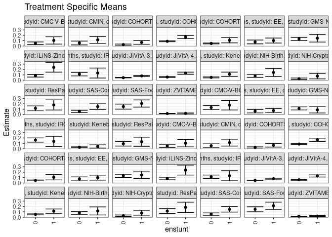

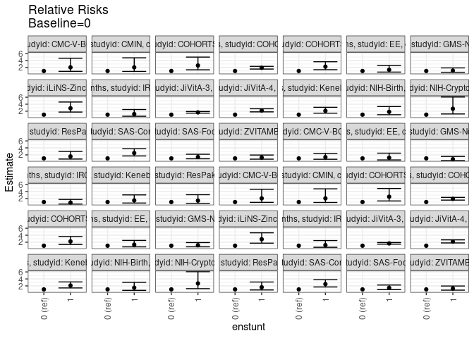

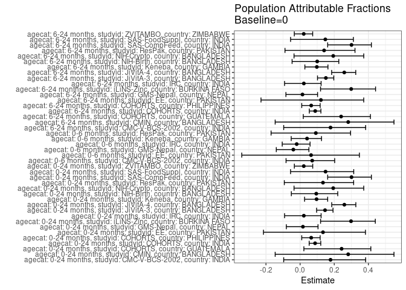

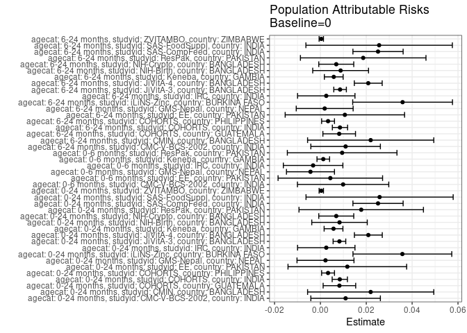

## Results Table

### Parameter: TSM

| agecat | studyid | country | intervention_level | baseline_level | estimate | ci_lower | ci_upper |
| --- | --- | --- | --- | --- | --- | --- | --- |
| 0-24 months | CMC-V-BCS-2002 | INDIA | 0 | NA | 0.0506757 | 0.0256554 | 0.0756960 |
| 0-24 months | CMC-V-BCS-2002 | INDIA | 1 | NA | 0.1038961 | 0.0356521 | 0.1721401 |
| 0-24 months | CMIN | BANGLADESH | 0 | NA | 0.0559006 | 0.0203458 | 0.0914555 |
| 0-24 months | CMIN | BANGLADESH | 1 | NA | 0.1145833 | 0.0507432 | 0.1784234 |
| 0-24 months | COHORTS | GUATEMALA | 0 | NA | 0.0258040 | 0.0151408 | 0.0364672 |
| 0-24 months | COHORTS | GUATEMALA | 1 | NA | 0.0666779 | 0.0327656 | 0.1005902 |
| 0-24 months | COHORTS | INDIA | 0 | NA | 0.0879567 | 0.0801977 | 0.0957157 |
| 0-24 months | COHORTS | INDIA | 1 | NA | 0.1676609 | 0.1373199 | 0.1980019 |
| 0-24 months | COHORTS | PHILIPPINES | 0 | NA | 0.0478971 | 0.0397648 | 0.0560293 |
| 0-24 months | COHORTS | PHILIPPINES | 1 | NA | 0.1073927 | 0.0583463 | 0.1564390 |
| 0-24 months | EE | PAKISTAN | 0 | NA | 0.0757981 | 0.0398415 | 0.1117548 |
| 0-24 months | EE | PAKISTAN | 1 | NA | 0.1016571 | 0.0550921 | 0.1482221 |
| 0-24 months | GMS-Nepal | NEPAL | 0 | NA | 0.1317933 | 0.1020992 | 0.1614873 |
| 0-24 months | GMS-Nepal | NEPAL | 1 | NA | 0.1448809 | 0.0737648 | 0.2159970 |
| 0-24 months | iLiNS-Zinc | BURKINA FASO | 0 | NA | 0.0840916 | 0.0600289 | 0.1081544 |
| 0-24 months | iLiNS-Zinc | BURKINA FASO | 1 | NA | 0.2393754 | 0.1515570 | 0.3271937 |
| 0-24 months | IRC | INDIA | 0 | NA | 0.1145251 | 0.0814977 | 0.1475526 |
| 0-24 months | IRC | INDIA | 1 | NA | 0.1346154 | 0.0417340 | 0.2274968 |
| 0-24 months | JiVitA-3 | BANGLADESH | 0 | NA | 0.0485306 | 0.0439597 | 0.0531014 |
| 0-24 months | JiVitA-3 | BANGLADESH | 1 | NA | 0.0805037 | 0.0714128 | 0.0895945 |
| 0-24 months | JiVitA-4 | BANGLADESH | 0 | NA | 0.0597657 | 0.0511457 | 0.0683856 |
| 0-24 months | JiVitA-4 | BANGLADESH | 1 | NA | 0.1319529 | 0.1123131 | 0.1515926 |
| 0-24 months | Keneba | GAMBIA | 0 | NA | 0.0536159 | 0.0441929 | 0.0630389 |
| 0-24 months | Keneba | GAMBIA | 1 | NA | 0.1127229 | 0.0731366 | 0.1523091 |
| 0-24 months | NIH-Birth | BANGLADESH | 0 | NA | 0.0796857 | 0.0547202 | 0.1046512 |
| 0-24 months | NIH-Birth | BANGLADESH | 1 | NA | 0.1450153 | 0.0703857 | 0.2196449 |
| 0-24 months | NIH-Crypto | BANGLADESH | 0 | NA | 0.0287081 | 0.0156287 | 0.0417876 |
| 0-24 months | NIH-Crypto | BANGLADESH | 1 | NA | 0.0776699 | 0.0259454 | 0.1293945 |
| 0-24 months | ResPak | PAKISTAN | 0 | NA | 0.1150172 | 0.0694721 | 0.1605622 |
| 0-24 months | ResPak | PAKISTAN | 1 | NA | 0.1779508 | 0.0843543 | 0.2715473 |

[output cut: 54 more lines]

### Parameter: E(Y)

| agecat | studyid | country | intervention_level | baseline_level | estimate | ci_lower | ci_upper |
| --- | --- | --- | --- | --- | --- | --- | --- |
| 0-24 months | CMC-V-BCS-2002 | INDIA | NA | NA | 0.0616622 | 0.0372186 | 0.0861058 |
| 0-24 months | CMIN | BANGLADESH | NA | NA | 0.0778210 | 0.0450051 | 0.1106369 |
| 0-24 months | COHORTS | GUATEMALA | NA | NA | 0.0340909 | 0.0231410 | 0.0450408 |
| 0-24 months | COHORTS | INDIA | NA | NA | 0.0964067 | 0.0887472 | 0.1040661 |
| 0-24 months | COHORTS | PHILIPPINES | NA | NA | 0.0512273 | 0.0430760 | 0.0593786 |
| 0-24 months | EE | PAKISTAN | NA | NA | 0.0875332 | 0.0589672 | 0.1160991 |
| 0-24 months | GMS-Nepal | NEPAL | NA | NA | 0.1340034 | 0.1066544 | 0.1613523 |
| 0-24 months | iLiNS-Zinc | BURKINA FASO | NA | NA | 0.1198322 | 0.0943748 | 0.1452897 |
| 0-24 months | IRC | INDIA | NA | NA | 0.1170732 | 0.0859146 | 0.1482317 |
| 0-24 months | JiVitA-3 | BANGLADESH | NA | NA | 0.0568247 | 0.0527145 | 0.0609348 |
| 0-24 months | JiVitA-4 | BANGLADESH | NA | NA | 0.0806665 | 0.0720540 | 0.0892791 |
| 0-24 months | Keneba | GAMBIA | NA | NA | 0.0593290 | 0.0499611 | 0.0686968 |
| 0-24 months | NIH-Birth | BANGLADESH | NA | NA | 0.0880150 | 0.0639627 | 0.1120673 |
| 0-24 months | NIH-Crypto | BANGLADESH | NA | NA | 0.0356164 | 0.0221630 | 0.0490699 |
| 0-24 months | ResPak | PAKISTAN | NA | NA | 0.1328125 | 0.0911588 | 0.1744662 |
| 0-24 months | SAS-CompFeed | INDIA | NA | NA | 0.0834553 | 0.0601989 | 0.1067118 |
| 0-24 months | SAS-FoodSuppl | INDIA | NA | NA | 0.1733333 | 0.1349698 | 0.2116969 |
| 0-24 months | ZVITAMBO | ZIMBABWE | NA | NA | 0.0176341 | 0.0149910 | 0.0202771 |
| 0-6 months | CMC-V-BCS-2002 | INDIA | NA | NA | 0.1396648 | 0.1037072 | 0.1756225 |
| 0-6 months | EE | PAKISTAN | NA | NA | 0.0673854 | 0.0418419 | 0.0929290 |
| 0-6 months | GMS-Nepal | NEPAL | NA | NA | 0.1093474 | 0.0836377 | 0.1350572 |
| 0-6 months | IRC | INDIA | NA | NA | 0.1592040 | 0.1233945 | 0.1950135 |
| 0-6 months | Keneba | GAMBIA | NA | NA | 0.0308068 | 0.0233159 | 0.0382978 |
| 0-6 months | ResPak | PAKISTAN | NA | NA | 0.1028807 | 0.0646041 | 0.1411572 |
| 6-24 months | CMC-V-BCS-2002 | INDIA | NA | NA | 0.0616622 | 0.0372186 | 0.0861058 |
| 6-24 months | CMIN | BANGLADESH | NA | NA | 0.0778210 | 0.0450051 | 0.1106369 |
| 6-24 months | COHORTS | GUATEMALA | NA | NA | 0.0340909 | 0.0231410 | 0.0450408 |
| 6-24 months | COHORTS | INDIA | NA | NA | 0.0964067 | 0.0887472 | 0.1040661 |
| 6-24 months | COHORTS | PHILIPPINES | NA | NA | 0.0512273 | 0.0430760 | 0.0593786 |
| 6-24 months | EE | PAKISTAN | NA | NA | 0.0875332 | 0.0589672 | 0.1160991 |
| 6-24 months | GMS-Nepal | NEPAL | NA | NA | 0.1340034 | 0.1066544 | 0.1613523 |
| 6-24 months | iLiNS-Zinc | BURKINA FASO | NA | NA | 0.1198322 | 0.0943748 | 0.1452897 |
| 6-24 months | IRC | INDIA | NA | NA | 0.1170732 | 0.0859146 | 0.1482317 |
| 6-24 months | JiVitA-3 | BANGLADESH | NA | NA | 0.0568247 | 0.0527145 | 0.0609348 |
| 6-24 months | JiVitA-4 | BANGLADESH | NA | NA | 0.0806665 | 0.0720540 | 0.0892791 |
| 6-24 months | Keneba | GAMBIA | NA | NA | 0.0593290 | 0.0499611 | 0.0686968 |
| 6-24 months | NIH-Birth | BANGLADESH | NA | NA | 0.0880150 | 0.0639627 | 0.1120673 |
| 6-24 months | NIH-Crypto | BANGLADESH | NA | NA | 0.0356164 | 0.0221630 | 0.0490699 |
| 6-24 months | ResPak | PAKISTAN | NA | NA | 0.1328125 | 0.0911588 | 0.1744662 |
| 6-24 months | SAS-CompFeed | INDIA | NA | NA | 0.0834553 | 0.0601989 | 0.1067118 |
| 6-24 months | SAS-FoodSuppl | INDIA | NA | NA | 0.1733333 | 0.1349698 | 0.2116969 |
| 6-24 months | ZVITAMBO | ZIMBABWE | NA | NA | 0.0176341 | 0.0149910 | 0.0202771 |

### Parameter: RR

| agecat | studyid | country | intervention_level | baseline_level | estimate | ci_lower | ci_upper |
| --- | --- | --- | --- | --- | --- | --- | --- |
| 0-24 months | CMC-V-BCS-2002 | INDIA | 0 | 0 | 1.0000000 | 1.0000000 | 1.000000 |
| 0-24 months | CMC-V-BCS-2002 | INDIA | 1 | 0 | 2.0502165 | 0.9014289 | 4.663027 |
| 0-24 months | CMIN | BANGLADESH | 0 | 0 | 1.0000000 | 1.0000000 | 1.000000 |
| 0-24 months | CMIN | BANGLADESH | 1 | 0 | 2.0497685 | 0.8800068 | 4.774453 |
| 0-24 months | COHORTS | GUATEMALA | 0 | 0 | 1.0000000 | 1.0000000 | 1.000000 |
| 0-24 months | COHORTS | GUATEMALA | 1 | 0 | 2.5840163 | 1.3416320 | 4.976879 |
| 0-24 months | COHORTS | INDIA | 0 | 0 | 1.0000000 | 1.0000000 | 1.000000 |
| 0-24 months | COHORTS | INDIA | 1 | 0 | 1.9061744 | 1.5589507 | 2.330735 |
| 0-24 months | COHORTS | PHILIPPINES | 0 | 0 | 1.0000000 | 1.0000000 | 1.000000 |
| 0-24 months | COHORTS | PHILIPPINES | 1 | 0 | 2.2421541 | 1.3773408 | 3.649972 |
| 0-24 months | EE | PAKISTAN | 0 | 0 | 1.0000000 | 1.0000000 | 1.000000 |
| 0-24 months | EE | PAKISTAN | 1 | 0 | 1.3411551 | 0.6937874 | 2.592576 |
| 0-24 months | GMS-Nepal | NEPAL | 0 | 0 | 1.0000000 | 1.0000000 | 1.000000 |
| 0-24 months | GMS-Nepal | NEPAL | 1 | 0 | 1.0993040 | 0.6401382 | 1.887826 |
| 0-24 months | iLiNS-Zinc | BURKINA FASO | 0 | 0 | 1.0000000 | 1.0000000 | 1.000000 |
| 0-24 months | iLiNS-Zinc | BURKINA FASO | 1 | 0 | 2.8466015 | 1.7509312 | 4.627903 |
| 0-24 months | IRC | INDIA | 0 | 0 | 1.0000000 | 1.0000000 | 1.000000 |
| 0-24 months | IRC | INDIA | 1 | 0 | 1.1754221 | 0.5564423 | 2.482948 |
| 0-24 months | JiVitA-3 | BANGLADESH | 0 | 0 | 1.0000000 | 1.0000000 | 1.000000 |
| 0-24 months | JiVitA-3 | BANGLADESH | 1 | 0 | 1.6588237 | 1.4373354 | 1.914443 |
| 0-24 months | JiVitA-4 | BANGLADESH | 0 | 0 | 1.0000000 | 1.0000000 | 1.000000 |
| 0-24 months | JiVitA-4 | BANGLADESH | 1 | 0 | 2.2078376 | 1.8062855 | 2.698658 |
| 0-24 months | Keneba | GAMBIA | 0 | 0 | 1.0000000 | 1.0000000 | 1.000000 |
| 0-24 months | Keneba | GAMBIA | 1 | 0 | 2.1024147 | 1.4198479 | 3.113114 |
| 0-24 months | NIH-Birth | BANGLADESH | 0 | 0 | 1.0000000 | 1.0000000 | 1.000000 |
| 0-24 months | NIH-Birth | BANGLADESH | 1 | 0 | 1.8198410 | 0.9953166 | 3.327405 |
| 0-24 months | NIH-Crypto | BANGLADESH | 0 | 0 | 1.0000000 | 1.0000000 | 1.000000 |
| 0-24 months | NIH-Crypto | BANGLADESH | 1 | 0 | 2.7055016 | 1.2073171 | 6.062814 |
| 0-24 months | ResPak | PAKISTAN | 0 | 0 | 1.0000000 | 1.0000000 | 1.000000 |
| 0-24 months | ResPak | PAKISTAN | 1 | 0 | 1.5471675 | 0.8005161 | 2.990230 |

[output cut: 54 more lines]

### Parameter: PAR

| agecat | studyid | country | intervention_level | baseline_level | estimate | ci_lower | ci_upper |
| --- | --- | --- | --- | --- | --- | --- | --- |
| 0-24 months | CMC-V-BCS-2002 | INDIA | 0 | NA | 0.0109865 | -0.0041772 | 0.0261502 |
| 0-24 months | CMIN | BANGLADESH | 0 | NA | 0.0219204 | -0.0055961 | 0.0494369 |
| 0-24 months | COHORTS | GUATEMALA | 0 | NA | 0.0082869 | 0.0011880 | 0.0153858 |
| 0-24 months | COHORTS | INDIA | 0 | NA | 0.0084499 | 0.0051240 | 0.0117759 |
| 0-24 months | COHORTS | PHILIPPINES | 0 | NA | 0.0033302 | 0.0005236 | 0.0061369 |
| 0-24 months | EE | PAKISTAN | 0 | NA | 0.0117350 | -0.0141362 | 0.0376063 |
| 0-24 months | GMS-Nepal | NEPAL | 0 | NA | 0.0022101 | -0.0102142 | 0.0146343 |
| 0-24 months | iLiNS-Zinc | BURKINA FASO | 0 | NA | 0.0357406 | 0.0141977 | 0.0572835 |
| 0-24 months | IRC | INDIA | 0 | NA | 0.0025480 | -0.0099714 | 0.0150675 |
| 0-24 months | JiVitA-3 | BANGLADESH | 0 | NA | 0.0082941 | 0.0055365 | 0.0110516 |
| 0-24 months | JiVitA-4 | BANGLADESH | 0 | NA | 0.0209009 | 0.0148269 | 0.0269748 |
| 0-24 months | Keneba | GAMBIA | 0 | NA | 0.0057131 | 0.0016174 | 0.0098087 |
| 0-24 months | NIH-Birth | BANGLADESH | 0 | NA | 0.0083293 | -0.0037732 | 0.0204317 |
| 0-24 months | NIH-Crypto | BANGLADESH | 0 | NA | 0.0069083 | -0.0007205 | 0.0145371 |
| 0-24 months | ResPak | PAKISTAN | 0 | NA | 0.0177953 | -0.0093443 | 0.0449350 |
| 0-24 months | SAS-CompFeed | INDIA | 0 | NA | 0.0251247 | 0.0141754 | 0.0360740 |
| 0-24 months | SAS-FoodSuppl | INDIA | 0 | NA | 0.0258075 | -0.0062801 | 0.0578952 |
| 0-24 months | ZVITAMBO | ZIMBABWE | 0 | NA | 0.0003792 | -0.0005709 | 0.0013294 |
| 0-6 months | CMC-V-BCS-2002 | INDIA | 0 | NA | 0.0098956 | -0.0100208 | 0.0298120 |
| 0-6 months | EE | PAKISTAN | 0 | NA | 0.0043208 | -0.0184704 | 0.0271119 |
| 0-6 months | GMS-Nepal | NEPAL | 0 | NA | -0.0043368 | -0.0148050 | 0.0061315 |
| 0-6 months | IRC | INDIA | 0 | NA | -0.0031892 | -0.0161740 | 0.0097956 |
| 0-6 months | Keneba | GAMBIA | 0 | NA | 0.0012528 | -0.0014934 | 0.0039991 |
| 0-6 months | ResPak | PAKISTAN | 0 | NA | 0.0094741 | -0.0144300 | 0.0333782 |
| 6-24 months | CMC-V-BCS-2002 | INDIA | 0 | NA | 0.0109865 | -0.0041772 | 0.0261502 |
| 6-24 months | CMIN | BANGLADESH | 0 | NA | 0.0219204 | -0.0055961 | 0.0494369 |
| 6-24 months | COHORTS | GUATEMALA | 0 | NA | 0.0081877 | 0.0010755 | 0.0152998 |
| 6-24 months | COHORTS | INDIA | 0 | NA | 0.0085284 | 0.0052060 | 0.0118508 |
| 6-24 months | COHORTS | PHILIPPINES | 0 | NA | 0.0033303 | 0.0005240 | 0.0061367 |
| 6-24 months | EE | PAKISTAN | 0 | NA | 0.0106648 | -0.0153720 | 0.0367016 |
| 6-24 months | GMS-Nepal | NEPAL | 0 | NA | 0.0018605 | -0.0105492 | 0.0142703 |
| 6-24 months | iLiNS-Zinc | BURKINA FASO | 0 | NA | 0.0358372 | 0.0140781 | 0.0575963 |
| 6-24 months | IRC | INDIA | 0 | NA | 0.0025480 | -0.0099714 | 0.0150675 |
| 6-24 months | JiVitA-3 | BANGLADESH | 0 | NA | 0.0085727 | 0.0058317 | 0.0113137 |
| 6-24 months | JiVitA-4 | BANGLADESH | 0 | NA | 0.0208631 | 0.0147863 | 0.0269399 |
| 6-24 months | Keneba | GAMBIA | 0 | NA | 0.0058120 | 0.0017164 | 0.0099076 |
| 6-24 months | NIH-Birth | BANGLADESH | 0 | NA | 0.0088110 | -0.0033620 | 0.0209839 |
| 6-24 months | NIH-Crypto | BANGLADESH | 0 | NA | 0.0069083 | -0.0007205 | 0.0145371 |
| 6-24 months | ResPak | PAKISTAN | 0 | NA | 0.0186616 | -0.0087132 | 0.0460365 |
| 6-24 months | SAS-CompFeed | INDIA | 0 | NA | 0.0251247 | 0.0141754 | 0.0360740 |
| 6-24 months | SAS-FoodSuppl | INDIA | 0 | NA | 0.0256044 | -0.0063312 | 0.0575399 |
| 6-24 months | ZVITAMBO | ZIMBABWE | 0 | NA | 0.0003747 | -0.0005757 | 0.0013252 |

### Parameter: PAF

| agecat | studyid | country | intervention_level | baseline_level | estimate | ci_lower | ci_upper |
| --- | --- | --- | --- | --- | --- | --- | --- |
| 0-24 months | CMC-V-BCS-2002 | INDIA | 0 | NA | 0.1781727 | -0.0961308 | 0.3838326 |
| 0-24 months | CMIN | BANGLADESH | 0 | NA | 0.2816770 | -0.1460941 | 0.5497857 |
| 0-24 months | COHORTS | GUATEMALA | 0 | NA | 0.2430831 | 0.0220034 | 0.4141870 |
| 0-24 months | COHORTS | INDIA | 0 | NA | 0.0876487 | 0.0531166 | 0.1209214 |
| 0-24 months | COHORTS | PHILIPPINES | 0 | NA | 0.0650089 | 0.0095185 | 0.1173905 |
| 0-24 months | EE | PAKISTAN | 0 | NA | 0.1340636 | -0.2147312 | 0.3827064 |
| 0-24 months | GMS-Nepal | NEPAL | 0 | NA | 0.0164927 | -0.0806893 | 0.1049355 |
| 0-24 months | iLiNS-Zinc | BURKINA FASO | 0 | NA | 0.2982553 | 0.1198837 | 0.4404767 |
| 0-24 months | IRC | INDIA | 0 | NA | 0.0217644 | -0.0911067 | 0.1229595 |
| 0-24 months | JiVitA-3 | BANGLADESH | 0 | NA | 0.1459589 | 0.0965908 | 0.1926292 |
| 0-24 months | JiVitA-4 | BANGLADESH | 0 | NA | 0.2591022 | 0.1851331 | 0.3263568 |
| 0-24 months | Keneba | GAMBIA | 0 | NA | 0.0962948 | 0.0261305 | 0.1614039 |
| 0-24 months | NIH-Birth | BANGLADESH | 0 | NA | 0.0946348 | -0.0514169 | 0.2203984 |
| 0-24 months | NIH-Crypto | BANGLADESH | 0 | NA | 0.1939639 | -0.0356867 | 0.3726924 |
| 0-24 months | ResPak | PAKISTAN | 0 | NA | 0.1339885 | -0.0925795 | 0.3135731 |
| 0-24 months | SAS-CompFeed | INDIA | 0 | NA | 0.3010559 | 0.1614149 | 0.4174439 |
| 0-24 months | SAS-FoodSuppl | INDIA | 0 | NA | 0.1488897 | -0.0560126 | 0.3140340 |
| 0-24 months | ZVITAMBO | ZIMBABWE | 0 | NA | 0.0215062 | -0.0337812 | 0.0738367 |
| 0-6 months | CMC-V-BCS-2002 | INDIA | 0 | NA | 0.0708524 | -0.0824181 | 0.2024198 |
| 0-6 months | EE | PAKISTAN | 0 | NA | 0.0641201 | -0.3418975 | 0.3472891 |
| 0-6 months | GMS-Nepal | NEPAL | 0 | NA | -0.0396604 | -0.1395689 | 0.0514888 |
| 0-6 months | IRC | INDIA | 0 | NA | -0.0200321 | -0.1048596 | 0.0582827 |
| 0-6 months | Keneba | GAMBIA | 0 | NA | 0.0406677 | -0.0521823 | 0.1253241 |
| 0-6 months | ResPak | PAKISTAN | 0 | NA | 0.0920879 | -0.1701059 | 0.2955301 |
| 6-24 months | CMC-V-BCS-2002 | INDIA | 0 | NA | 0.1781727 | -0.0961308 | 0.3838326 |
| 6-24 months | CMIN | BANGLADESH | 0 | NA | 0.2816770 | -0.1460941 | 0.5497857 |
| 6-24 months | COHORTS | GUATEMALA | 0 | NA | 0.2401713 | 0.0184665 | 0.4117983 |
| 6-24 months | COHORTS | INDIA | 0 | NA | 0.0884629 | 0.0539863 | 0.1216831 |
| 6-24 months | COHORTS | PHILIPPINES | 0 | NA | 0.0650103 | 0.0095236 | 0.1173886 |
| 6-24 months | EE | PAKISTAN | 0 | NA | 0.1218376 | -0.2291439 | 0.3725965 |
| 6-24 months | GMS-Nepal | NEPAL | 0 | NA | 0.0138843 | -0.0831658 | 0.1022388 |
| 6-24 months | iLiNS-Zinc | BURKINA FASO | 0 | NA | 0.2990614 | 0.1196642 | 0.4419005 |
| 6-24 months | IRC | INDIA | 0 | NA | 0.0217644 | -0.0911067 | 0.1229595 |
| 6-24 months | JiVitA-3 | BANGLADESH | 0 | NA | 0.1508622 | 0.1018371 | 0.1972113 |
| 6-24 months | JiVitA-4 | BANGLADESH | 0 | NA | 0.2586336 | 0.1846930 | 0.3258685 |
| 6-24 months | Keneba | GAMBIA | 0 | NA | 0.0979619 | 0.0278220 | 0.1630414 |
| 6-24 months | NIH-Birth | BANGLADESH | 0 | NA | 0.1001075 | -0.0470354 | 0.2265719 |
| 6-24 months | NIH-Crypto | BANGLADESH | 0 | NA | 0.1939639 | -0.0356867 | 0.3726924 |
| 6-24 months | ResPak | PAKISTAN | 0 | NA | 0.1405110 | -0.0886960 | 0.3214622 |
| 6-24 months | SAS-CompFeed | INDIA | 0 | NA | 0.3010559 | 0.1614149 | 0.4174439 |
| 6-24 months | SAS-FoodSuppl | INDIA | 0 | NA | 0.1477176 | -0.0557959 | 0.3120021 |
| 6-24 months | ZVITAMBO | ZIMBABWE | 0 | NA | 0.0212501 | -0.0340564 | 0.0735986 |